# Heart Disease Prediction

Simranjit

2022-10-28

```r
library(ISLR)
library(tidyverse)
library(kableExtra)
library(rsample)
library(parsnip)
library(magrittr)
library(gbm)
library(yardstick)
library(viridisLite)
```

##Read the Data The first part of the analysis is to read in the data set

```r
Dataset <-read_csv("C:/Users/L.Singh/OneDrive/Bureaublad/simran/data/heart.csv")
glimpse(Dataset)
```

```
## Rows: 303
## Columns: 14
## $ age      <dbl> 63, 37, 41, 56, 57, 57, 56, 44, 52, 57, 54, 48, 49, 64, 58, 5…
## $ sex      <dbl> 1, 1, 0, 1, 0, 1, 0, 1, 1, 1, 1, 0, 1, 1, 0, 0, 0, 0, 1, 0, 1…
## $ cp       <dbl> 3, 2, 1, 1, 0, 0, 1, 1, 2, 2, 0, 2, 1, 3, 3, 2, 2, 3, 0, 3, 0…
## $ trestbps <dbl> 145, 130, 130, 120, 120, 140, 140, 120, 172, 150, 140, 130, 1…
## $ chol     <dbl> 233, 250, 204, 236, 354, 192, 294, 263, 199, 168, 239, 275, 2…
## $ fbs      <dbl> 1, 0, 0, 0, 0, 0, 0, 0, 1, 0, 0, 0, 0, 0, 1, 0, 0, 0, 0, 0, 0…
## $ restecg  <dbl> 0, 1, 0, 1, 1, 1, 0, 1, 1, 1, 1, 1, 1, 0, 0, 1, 1, 1, 1, 1, 1…
## $ thalach  <dbl> 150, 187, 172, 178, 163, 148, 153, 173, 162, 174, 160, 139, 1…
## $ exang    <dbl> 0, 0, 0, 0, 1, 0, 0, 0, 0, 0, 0, 0, 0, 1, 0, 0, 0, 0, 0, 0, 0…
## $ oldpeak  <dbl> 2.3, 3.5, 1.4, 0.8, 0.6, 0.4, 1.3, 0.0, 0.5, 1.6, 1.2, 0.2, 0…
## $ slope    <dbl> 0, 0, 2, 2, 2, 1, 1, 2, 2, 2, 2, 2, 2, 1, 2, 1, 2, 0, 2, 2, 1…
## $ ca       <dbl> 0, 0, 0, 0, 0, 0, 0, 0, 0, 0, 0, 0, 0, 0, 0, 0, 0, 0, 0, 2, 0…
## $ thal     <dbl> 1, 2, 2, 2, 2, 1, 2, 3, 3, 2, 2, 2, 2, 2, 2, 2, 2, 2, 2, 2, 3…
## $ target   <dbl> 1, 1, 1, 1, 1, 1, 1, 1, 1, 1, 1, 1, 1, 1, 1, 1, 1, 1, 1, 1, 1…
```

```r
dim(Dataset)
```

```
## [1] 303  14
```

```r
nrow(Dataset)
```

```
## [1] 303
```

```r
summary(Dataset)
```

```
##       age             sex               cp           trestbps
##  Min.   :29.00   Min.   :0.0000   Min.   :0.000   Min.   : 94.0
##  1st Qu.:47.50   1st Qu.:0.0000   1st Qu.:0.000   1st Qu.:120.0
##  Median :55.00   Median :1.0000   Median :1.000   Median :130.0
##  Mean   :54.37   Mean   :0.6832   Mean   :0.967   Mean   :131.6
##  3rd Qu.:61.00   3rd Qu.:1.0000   3rd Qu.:2.000   3rd Qu.:140.0
##  Max.   :77.00   Max.   :1.0000   Max.   :3.000   Max.   :200.0
##       chol            fbs            restecg          thalach
##  Min.   :126.0   Min.   :0.0000   Min.   :0.0000   Min.   : 71.0
##  1st Qu.:211.0   1st Qu.:0.0000   1st Qu.:0.0000   1st Qu.:133.5
##  Median :240.0   Median :0.0000   Median :1.0000   Median :153.0
##  Mean   :246.3   Mean   :0.1485   Mean   :0.5281   Mean   :149.6
##  3rd Qu.:274.5   3rd Qu.:0.0000   3rd Qu.:1.0000   3rd Qu.:166.0
##  Max.   :564.0   Max.   :1.0000   Max.   :2.0000   Max.   :202.0
##      exang           oldpeak         slope             ca
##  Min.   :0.0000   Min.   :0.00   Min.   :0.000   Min.   :0.0000
##  1st Qu.:0.0000   1st Qu.:0.00   1st Qu.:1.000   1st Qu.:0.0000
##  Median :0.0000   Median :0.80   Median :1.000   Median :0.0000
##  Mean   :0.3267   Mean   :1.04   Mean   :1.399   Mean   :0.7294
##  3rd Qu.:1.0000   3rd Qu.:1.60   3rd Qu.:2.000   3rd Qu.:1.0000
##  Max.   :1.0000   Max.   :6.20   Max.   :2.000   Max.   :4.0000
##       thal           target
##  Min.   :0.000   Min.   :0.0000
##  1st Qu.:2.000   1st Qu.:0.0000
##  Median :2.000   Median :1.0000
##  Mean   :2.314   Mean   :0.5446
##  3rd Qu.:3.000   3rd Qu.:1.0000
##  Max.   :3.000   Max.   :1.0000
```

```r
head(Dataset)
```

```
## # A tibble: 6 × 14
##     age   sex    cp trestbps  chol   fbs restecg thalach exang oldpeak slope
##   <dbl> <dbl> <dbl>    <dbl> <dbl> <dbl>   <dbl>   <dbl> <dbl>   <dbl> <dbl>
## 1    63     1     3      145   233     1       0     150     0     2.3     0
## 2    37     1     2      130   250     0       1     187     0     3.5     0
## 3    41     0     1      130   204     0       0     172     0     1.4     2
## 4    56     1     1      120   236     0       1     178     0     0.8     2
## 5    57     0     0      120   354     0       1     163     1     0.6     2
## 6    57     1     0      140   192     0       1     148     0     0.4     1
## # … with 3 more variables: ca <dbl>, thal <dbl>, target <dbl>
```

```r
str(Dataset)
```

```
## spc_tbl_ [303 × 14] (S3: spec_tbl_df/tbl_df/tbl/data.frame)
##  $ age     : num [1:303] 63 37 41 56 57 57 56 44 52 57 ...
##  $ sex     : num [1:303] 1 1 0 1 0 1 0 1 1 1 ...
##  $ cp      : num [1:303] 3 2 1 1 0 0 1 1 2 2 ...
##  $ trestbps: num [1:303] 145 130 130 120 120 140 140 120 172 150 ...
##  $ chol    : num [1:303] 233 250 204 236 354 192 294 263 199 168 ...
##  $ fbs     : num [1:303] 1 0 0 0 0 0 0 0 1 0 ...
##  $ restecg : num [1:303] 0 1 0 1 1 1 0 1 1 1 ...
##  $ thalach : num [1:303] 150 187 172 178 163 148 153 173 162 174 ...
##  $ exang   : num [1:303] 0 0 0 0 1 0 0 0 0 0 ...
##  $ oldpeak : num [1:303] 2.3 3.5 1.4 0.8 0.6 0.4 1.3 0 0.5 1.6 ...
##  $ slope   : num [1:303] 0 0 2 2 2 1 1 2 2 2 ...
##  $ ca      : num [1:303] 0 0 0 0 0 0 0 0 0 0 ...
##  $ thal    : num [1:303] 1 2 2 2 2 1 2 3 3 2 ...
##  $ target  : num [1:303] 1 1 1 1 1 1 1 1 1 1 ...
##  - attr(*, "spec")=
##   .. cols(
##   ..   age = col_double(),
##   ..   sex = col_double(),
##   ..   cp = col_double(),
##   ..   trestbps = col_double(),
##   ..   chol = col_double(),
##   ..   fbs = col_double(),
##   ..   restecg = col_double(),
##   ..   thalach = col_double(),
##   ..   exang = col_double(),
##   ..   oldpeak = col_double(),
##   ..   slope = col_double(),
##   ..   ca = col_double(),
##   ..   thal = col_double(),
##   ..   target = col_double()
##   .. )
##  - attr(*, "problems")=<externalptr>
```

There are 14 variables provided in the data set and the last one is the dependent variable that we want to be able to predict. Here is a summary of what the other variables mean:

1.**Age**: Age of subject

2.**Sex**: Gender of subject: 0 = female 1 = male

3.**Chest-pain type**: Type of chest-pain experienced by the individual: 1 = typical angina 2 = atypical angina 3 = non-angina pain 4 = asymptomatic angina

4.**Resting Blood Pressure**: Resting blood pressure in mm Hg

5. **Cholesterol**: Serum cholesterol in mg/dl

6.**Fasting Blood Sugar**: Fasting blood sugar level relative to 120 mg/dl: 0 = fasting blood sugar <= 120 mg/dl 1 = fasting blood sugar > 120 mg/dl

7. **Resting ECG**: Resting electrocardiographic results 0 = normal 1 = ST-T wave abnormality 2 = left ventricle hyperthrophy

8.**thalach**Max Heart Rate Achieved: Max heart rate of subject

9.**exang** Exercise Induced Angina: 0 = no 1 = yes

10.**oldpeak**ST Depression Induced by Exercise Relative to Rest: ST Depression of subject

11.**slope** Peak Exercise ST Segment: 1 = Up-sloaping 2 = Flat 3 = Down-sloaping

12.**ca** Number of Major Vessels (0-3) Visible on Flouroscopy: Number of visible vessels under flouro

13.**Thal**: Form of thalassemia: 3 3 = normal 6 = fixed defect 7 = reversible defect

14.**Target**: Indicates whether subject is suffering from heart disease or not: 0 = absence 1 = heart disease present

**Missing values in the dataset** Missing values can be problematic if present. We can also check to see if there is missing data.

```r
library(DataExplorer)
library(ggplot2)
colSums(is.na(Dataset))
```

```
##      age      sex       cp trestbps     chol      fbs  restecg  thalach
##        0        0        0        0        0        0        0        0
##    exang  oldpeak    slope       ca     thal   target
##        0        0        0        0        0        0
```

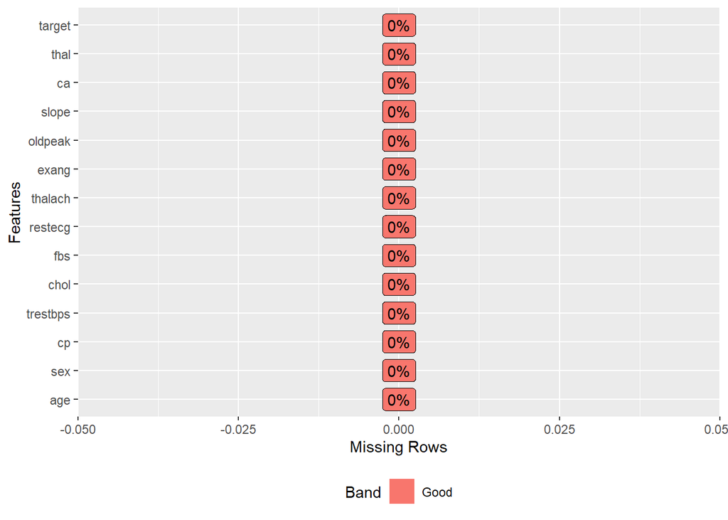

```r
plot_missing(Dataset)
```

As we can see above, there aren’t any missing values across our dataset, which will make it easier for us as we start to prepare our dataset for machine learning analysis. **Implementing Changes**

```r
Dataset$sex<-as.factor(Dataset$sex)
levels(Dataset$sex)<-c("0","1")
Dataset$cp<-as.factor(Dataset$cp)
levels(Dataset$cp)<-c("typical","atypical","non-anginal","asymptomatic")
Dataset$fbs<-as.factor(Dataset$fbs)
levels(Dataset$fbs)<-c("False","True")
Dataset$restecg<-as.factor(Dataset$restecg)
levels(Dataset$restecg)<-c("normal","stt","hypertrophy")
Dataset$exang<-as.factor(Dataset$exang)
levels(Dataset$exang)<-c("No","Yes")
Dataset$slope<-as.factor(Dataset$slope)
levels(Dataset$slope)<-c("upsloping","flat","downsloping")
Dataset$ca<-as.factor(Dataset$ca)

Dataset$target<-as.factor(Dataset$target)
levels(Dataset$target)<-c("No", "Yes")
```

**To see wheteher the changes are implemented**

```r
str(Dataset)
```

```
## spc_tbl_ [303 × 14] (S3: spec_tbl_df/tbl_df/tbl/data.frame)
##  $ age     : num [1:303] 63 37 41 56 57 57 56 44 52 57 ...
##  $ sex     : Factor w/ 2 levels "0","1": 2 2 1 2 1 2 1 2 2 2 ...
##  $ cp      : Factor w/ 4 levels "typical","atypical",..: 4 3 2 2 1 1 2 2 3 3 ...
##  $ trestbps: num [1:303] 145 130 130 120 120 140 140 120 172 150 ...
##  $ chol    : num [1:303] 233 250 204 236 354 192 294 263 199 168 ...
##  $ fbs     : Factor w/ 2 levels "False","True": 2 1 1 1 1 1 1 1 2 1 ...
##  $ restecg : Factor w/ 3 levels "normal","stt",..: 1 2 1 2 2 2 1 2 2 2 ...
##  $ thalach : num [1:303] 150 187 172 178 163 148 153 173 162 174 ...
##  $ exang   : Factor w/ 2 levels "No","Yes": 1 1 1 1 2 1 1 1 1 1 ...
##  $ oldpeak : num [1:303] 2.3 3.5 1.4 0.8 0.6 0.4 1.3 0 0.5 1.6 ...
##  $ slope   : Factor w/ 3 levels "upsloping","flat",..: 1 1 3 3 3 2 2 3 3 3 ...
##  $ ca      : Factor w/ 5 levels "0","1","2","3",..: 1 1 1 1 1 1 1 1 1 1 ...
##  $ thal    : num [1:303] 1 2 2 2 2 1 2 3 3 2 ...
##  $ target  : Factor w/ 2 levels "No","Yes": 2 2 2 2 2 2 2 2 2 2 ...
##  - attr(*, "spec")=
##   .. cols(
##   ..   age = col_double(),
##   ..   sex = col_double(),
##   ..   cp = col_double(),
##   ..   trestbps = col_double(),
##   ..   chol = col_double(),
##   ..   fbs = col_double(),
##   ..   restecg = col_double(),
##   ..   thalach = col_double(),
##   ..   exang = col_double(),
##   ..   oldpeak = col_double(),
##   ..   slope = col_double(),
##   ..   ca = col_double(),
##   ..   thal = col_double(),
##   ..   target = col_double()
##   .. )
##  - attr(*, "problems")=<externalptr>
```

```r
summary(Dataset)
```

```
##       age        sex                cp         trestbps          chol
##  Min.   :29.00   0: 96   typical     :143   Min.   : 94.0   Min.   :126.0
##  1st Qu.:47.50   1:207   atypical    : 50   1st Qu.:120.0   1st Qu.:211.0
##  Median :55.00           non-anginal : 87   Median :130.0   Median :240.0
##  Mean   :54.37           asymptomatic: 23   Mean   :131.6   Mean   :246.3
##  3rd Qu.:61.00                              3rd Qu.:140.0   3rd Qu.:274.5
##  Max.   :77.00                              Max.   :200.0   Max.   :564.0
##     fbs             restecg       thalach      exang        oldpeak
##  False:258   normal     :147   Min.   : 71.0   No :204   Min.   :0.00
##  True : 45   stt        :152   1st Qu.:133.5   Yes: 99   1st Qu.:0.00
##              hypertrophy:  4   Median :153.0             Median :0.80
##                                Mean   :149.6             Mean   :1.04
##                                3rd Qu.:166.0             3rd Qu.:1.60
##                                Max.   :202.0             Max.   :6.20
##          slope     ca           thal       target
##  upsloping  : 21   0:175   Min.   :0.000   No :138
##  flat       :140   1: 65   1st Qu.:2.000   Yes:165
##  downsloping:142   2: 38   Median :2.000
##                    3: 20   Mean   :2.314
##                    4:  5   3rd Qu.:3.000
##                            Max.   :3.000
```

**EDA**

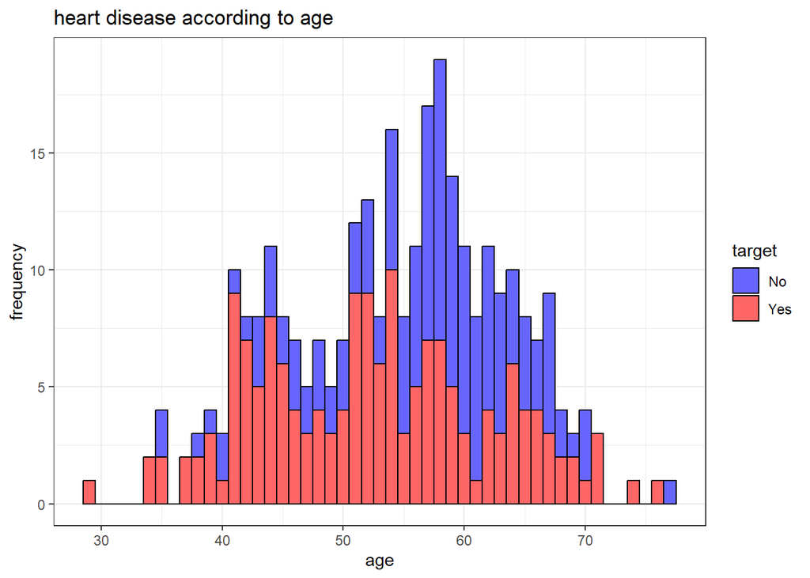

```r
ggplot(Dataset, aes(x = age, fill = target, color = target)) + geom_histogram(binwidth = 1,colour = "Black") + labs(x = "age", y = "frequency",title = "heart disease according to age") + theme_bw() + scale_fill_manual(values = c("Yes" = "#FF6666" , "No" = "#6666FF"))
```

```r
table(Dataset$target)
```

```
##
##  No Yes
## 138 165
```

```r
165/303
```

```
## [1] 0.5445545
```

```r
#Probability of heart disease is 0.54 means 54% of patients suffering from heart disease.
```

**correlation matrix**

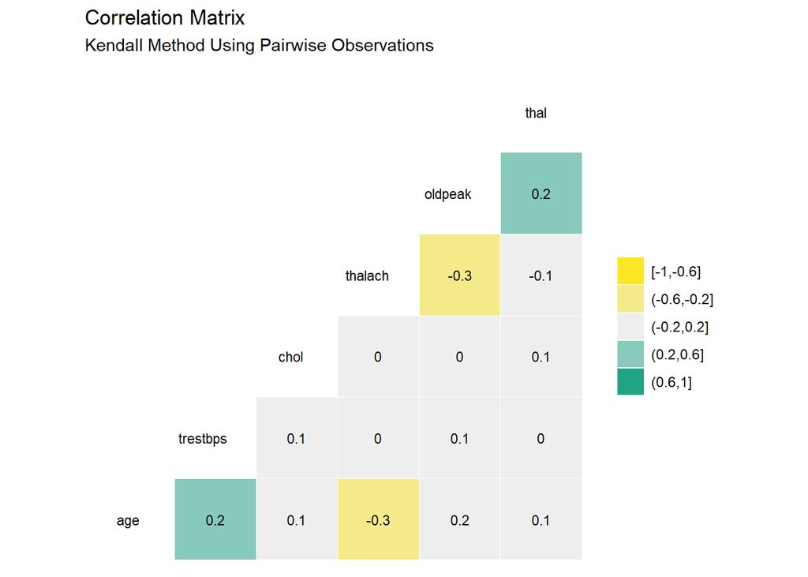

```r
library(GGally)
Dataset %>% ggcorr(method  = c("pairwise", "kendall"),
                                   high       = "#20a486ff",
                                   low        = "#fde725ff",
                                   label      = TRUE,
                                   hjust      = .75,
                                   size       = 3,
                                   label_size = 3,
                                   nbreaks    = 5
                                   ) +
  labs(title = "Correlation Matrix",
  subtitle = "Kendall Method Using Pairwise Observations")
```

No variables appear to be highly correlated. As such, it seems reasonable to stay with the original 14 variables as we proceed further. **Build the model** **Splitting the Dataset into training set() and testing set()**

```r
set.seed(100)
sample <- sample(c(TRUE, FALSE), nrow(Dataset), replace=TRUE, prob=c(0.80,0.20))
train  <- Dataset[sample, ]
test   <- Dataset[!sample, ]
```

The Dataset is divided into training 80% and testing data 20%

```r
lr<-glm(target~.,data = train,family = "binomial")
```

To check well how model is generated, and then built the confusion matrix to know the accuracy of the model.

```r
train$pred<-fitted(lr)
head(train)
```

```
## # A tibble: 6 × 15
##     age sex   cp         trest…¹  chol fbs   restecg thalach exang oldpeak slope
##   <dbl> <fct> <fct>        <dbl> <dbl> <fct> <fct>     <dbl> <fct>   <dbl> <fct>
## 1    63 1     asymptoma…     145   233 True  normal      150 No        2.3 upsl…
## 2    37 1     non-angin…     130   250 False stt         187 No        3.5 upsl…
## 3    41 0     atypical       130   204 False normal      172 No        1.4 down…
## 4    56 1     atypical       120   236 False stt         178 No        0.8 down…
## 5    57 0     typical        120   354 False stt         163 Yes       0.6 down…
## 6    57 1     typical        140   192 False stt         148 No        0.4 flat
## # … with 4 more variables: ca <fct>, thal <dbl>, target <fct>, pred <dbl>, and
## #   abbreviated variable name ¹trestbps
```

As we can see that the predicted score in probability of having heart disease. But we have to distinguish between having heart disease or not which we can determine from ROC curve.

```r
Dataset %>%
  group_by(target) %>%
  summarise(mean=mean(trestbps))
```

```
## # A tibble: 2 × 2
##   target  mean
##   <fct>  <dbl>
## 1 No      134.
## 2 Yes     129.
```

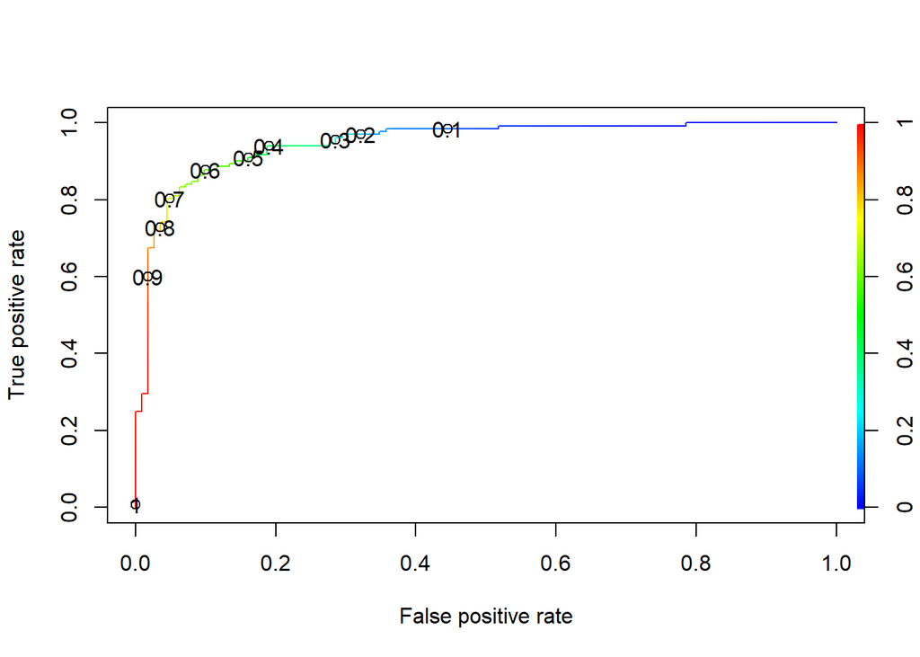

```r
library(ROCR)
pred<-prediction(train$pred,train$target)
perf<-performance(pred,"tpr","fpr")
plot(perf,colorize = T,print.cutoffs.at = seq(0.1,by = 0.1))
```

With the ROC curve we can observe that 0.6 is having better sensitivity and specificity . There 0.6 is selected as our cutoff to distinguish.

```r
#Area under curve

Auc = as.numeric(performance(pred, 'auc')@y.values)
Auc
```

```
## [1] 0.9486607
```

```r
train$pred1<-ifelse(train$pred<0.6,"No","Yes")
library(caret)
confusionMatrix(factor(train$pred1),train$target)
```

```
## Confusion Matrix and Statistics
##
##           Reference
## Prediction  No Yes
##        No  101  16
##        Yes  11 116
##
##                Accuracy : 0.8893
##                  95% CI : (0.8431, 0.9258)
##     No Information Rate : 0.541
##     P-Value [Acc > NIR] : <2e-16
##
##                   Kappa : 0.7779
##
##  Mcnemar's Test P-Value : 0.4414
##
##             Sensitivity : 0.9018
##             Specificity : 0.8788
##          Pos Pred Value : 0.8632
##          Neg Pred Value : 0.9134
##              Prevalence : 0.4590
##          Detection Rate : 0.4139
##    Detection Prevalence : 0.4795
##       Balanced Accuracy : 0.8903
##
##        'Positive' Class : No
##
```

#Here we find that the accuracy of the model is 88.93% is accurate.

**Random Forest**

```r
library(randomForest)
set.seed(100)
model_rf<-randomForest(target~.,data = train)
model_rf
```

```
##
## Call:
##  randomForest(formula = target ~ ., data = train)
##                Type of random forest: classification
##                      Number of trees: 500
## No. of variables tried at each split: 3
##
##         OOB estimate of  error rate: 13.52%
## Confusion matrix:
##     No Yes class.error
## No  95  17   0.1517857
## Yes 16 116   0.1212121
```

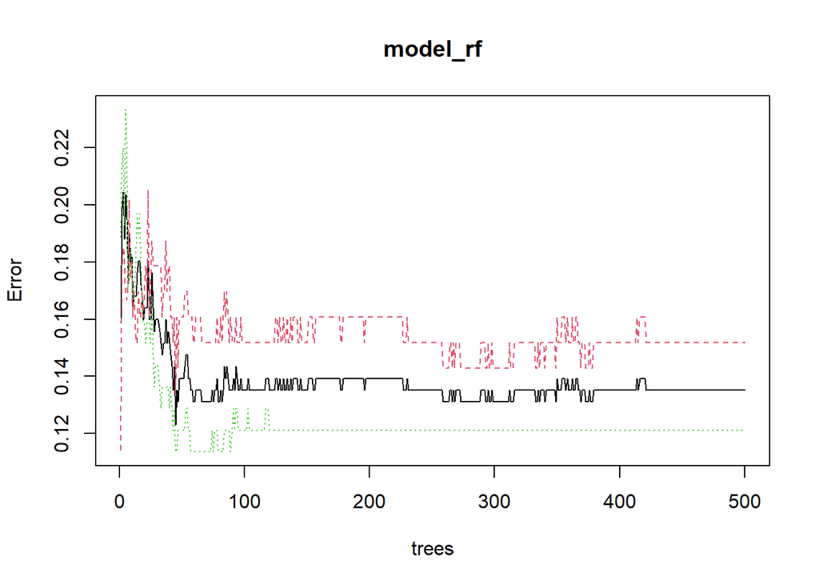

```r
plot(model_rf)
```

The plot above shows the Error and the Number of Trees as a result of our random forest analysis. We can very easily see that the Error drops dramatically as more trees are added and averaged. For reference, the red line represents the MCR of class designated as not having heart disease in our training set, whereas the green line represents the MCR of class designated as having heart disease in our training set. Additionally, the black line represents the overall MCR or OOB error. The overall error rate is what we are interested in which seems considerably good.

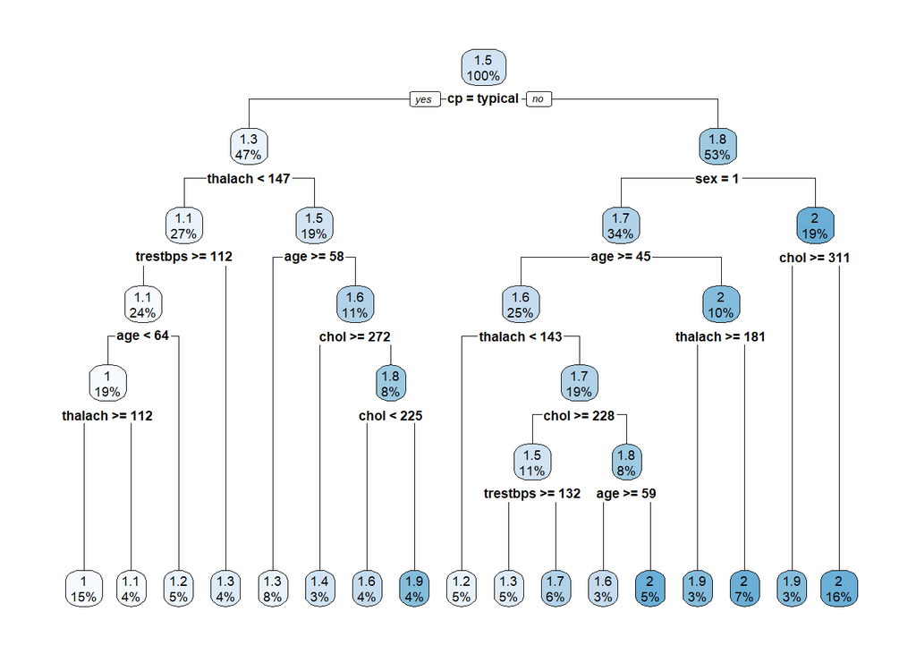

```r
library(rpart)
library(rpart.plot)
tree<-rpart(target~age + sex + cp + trestbps + chol + restecg + thalach + target,method = "anova",data = train, cp = 0.001)
rpart.plot(tree)
```

**Bagging**

```r
cvcontrol <- trainControl(method = "repeatedcv",
                          number = 10,
                          allowParallel = TRUE)

bag_train <- train(target~age + sex + cp + trestbps + chol + restecg + thalach + target,
                   data = train,
                   method = 'treebag',
                   trControl = cvcontrol,
                   importance = TRUE)
```

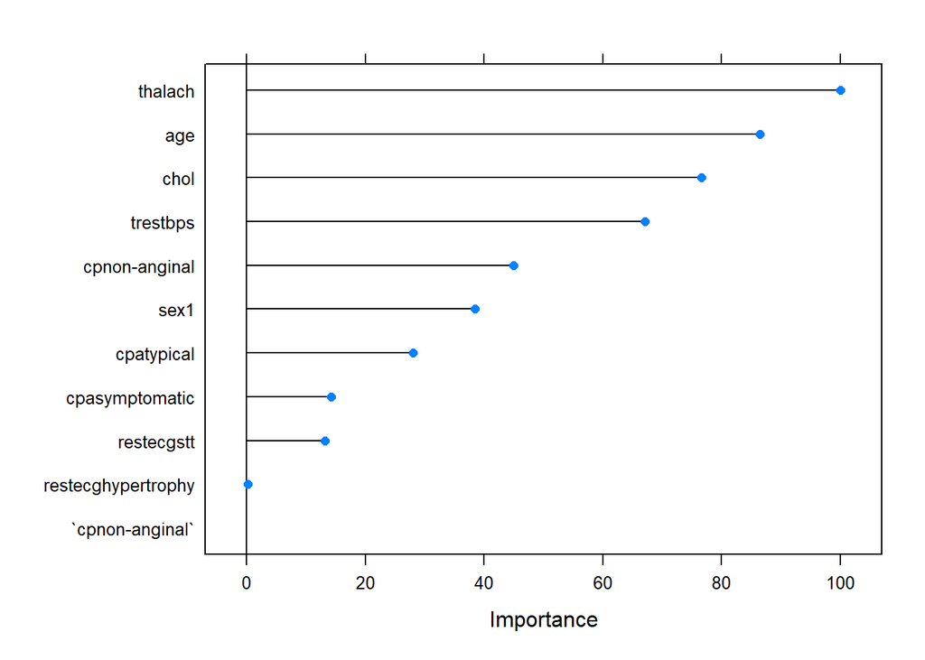

```r
bag_train %>%
  varImp %>%
  plot
```

From bagging we find that most important factor are thalach,age,choland trestbps.

```r
confusionMatrix(predict(bag_train, type = "raw"),
                train$target)
```

```
## Confusion Matrix and Statistics
##
##           Reference
## Prediction  No Yes
##        No  111   0
##        Yes   1 132
##
##                Accuracy : 0.9959
##                  95% CI : (0.9774, 0.9999)
##     No Information Rate : 0.541
##     P-Value [Acc > NIR] : <2e-16
##
##                   Kappa : 0.9917
##
##  Mcnemar's Test P-Value : 1
##
##             Sensitivity : 0.9911
##             Specificity : 1.0000
##          Pos Pred Value : 1.0000
##          Neg Pred Value : 0.9925
##              Prevalence : 0.4590
##          Detection Rate : 0.4549
##    Detection Prevalence : 0.4549
##       Balanced Accuracy : 0.9955
##
##        'Positive' Class : No
##
```

```r
bag_train
```

```
## Bagged CART
##
## 244 samples
##   7 predictor
##   2 classes: 'No', 'Yes'
##
## No pre-processing
## Resampling: Cross-Validated (10 fold, repeated 1 times)
## Summary of sample sizes: 220, 220, 220, 219, 219, 220, ...
## Resampling results:
##
##   Accuracy   Kappa
##   0.7213333  0.4336892
```

**Gradient Boosting**

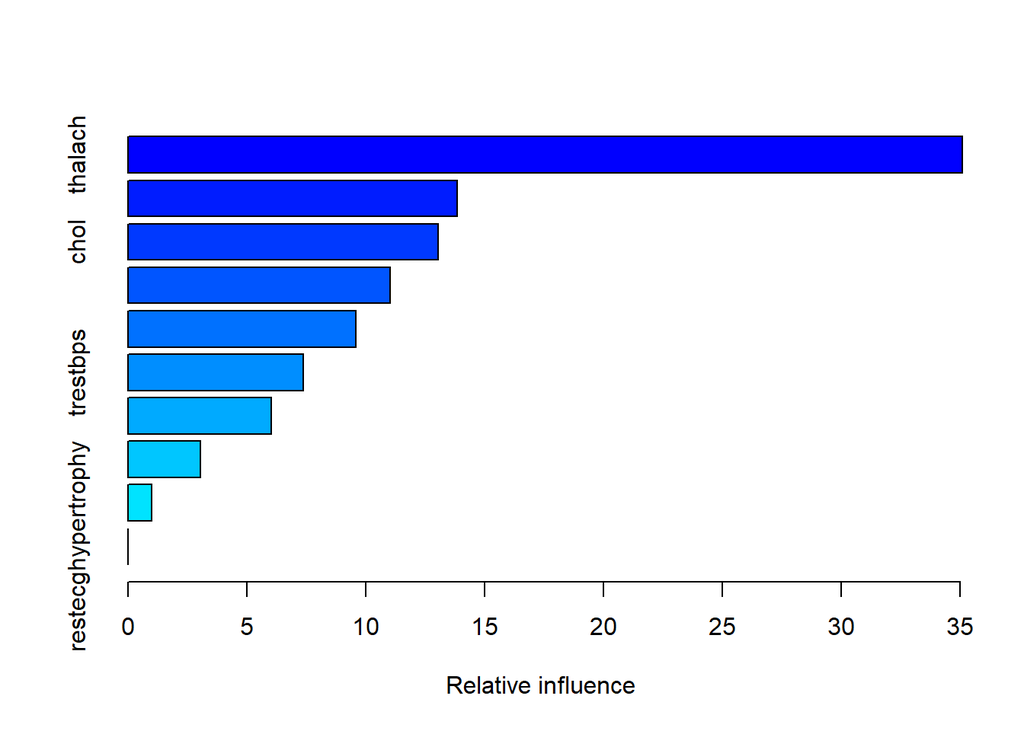

```
##                                   var   rel.inf
## thalach                       thalach 35.081727
## age                               age 13.840460
## chol                             chol 13.043527
## sex1                             sex1 11.012396
## cpnon-anginal           cpnon-anginal  9.571504
## trestbps                     trestbps  7.372434
## cpatypical                 cpatypical  6.014770
## cpasymptomatic         cpasymptomatic  3.057766
## restecgstt                 restecgstt  1.005417
## restecghypertrophy restecghypertrophy  0.000000
```

```r
gbm_train <- train(target~ age + sex + cp + trestbps + chol + restecg + thalach + target,
                   data = train,
                    verbose = 5,

                   method = "gbm",

                   trControl = cvcontrol)
summary(gbm_train)
```

```r
gbm_train
```

```
## Stochastic Gradient Boosting
##
## 244 samples
##   7 predictor
##   2 classes: 'No', 'Yes'
##
## No pre-processing
## Resampling: Cross-Validated (10 fold, repeated 1 times)
## Summary of sample sizes: 220, 219, 219, 220, 220, 219, ...
## Resampling results across tuning parameters:
##
##   interaction.depth  n.trees  Accuracy   Kappa
##   1                   50      0.7373333  0.4676910
##   1                  100      0.7578333  0.5107194
##   1                  150      0.7493333  0.4940916
##   2                   50      0.7540000  0.5049175
##   2                  100      0.7456667  0.4901895
##   2                  150      0.7456667  0.4883097
##   3                   50      0.7701667  0.5376634
##   3                  100      0.7621667  0.5203911
##   3                  150      0.7128333  0.4216066
##
## Tuning parameter 'shrinkage' was held constant at a value of 0.1
##
## Tuning parameter 'n.minobsinnode' was held constant at a value of 10
## Accuracy was used to select the optimal model using the largest value.
## The final values used for the model were n.trees = 50, interaction.depth =
##  3, shrinkage = 0.1 and n.minobsinnode = 10.
```

##Conclusion Heart diseases are considered to be one of the main reasons that lead to the death. The correct prediction of heart disease can prevent life threats, however incorrect prediction can be fatal at the same time. I have considered the ways to solve the problem of prediction cardiovasculars diseases using Random forest,Bagging and this intresting conclusions are derived.